# R Notebook

Author: Joss Ives, *updated by Joss Ives 2018 May 27, 16:28:04*.

# Setup

## Load libraries

```r
suppressWarnings(library(lme4))
require(lme4)
suppressWarnings(library(ggplot2))
require(ggplot2)
source("jossfunc.R")
```

## Data files

### Load data

```r
dat.raw <- read.csv("C:/Users/Joss/ownCloud/Shared/DP_Derived_Data/dpLogisticDat.csv")
```

### Add additional calculated values

```r
dat.raw$course.grade.frac <- dat.raw$course.grade/100.
dat.raw$CRT.medsplit <- trunc(dat.raw$NCRT/2)
dat.raw$final.grade.LMH <- as.integer(
  cut(dat.raw$f.tot78, quantile(dat.raw$f.tot78, probs=0:3/3), include.lowest=TRUE)
  )
dat.raw$final.grade.fix <- (dat.raw$f.tot78-2.*dat.raw$QCORRECT)/76.
dat.raw$final.gradeA.fix <- (dat.raw$f.Atot40-2.*dat.raw$QCORRECT)/38.
names(dat.raw)
```

```
 [1] "ID"                "QNUM"              "QCORRECT"          "TREATMENT"         "f.Atot40"          "f.Btot38"
 [7] "f.tot78"           "course.grade"      "d.version"         "f.version"         "NCRT"              "Gender"
[13] "course.grade.frac" "CRT.medsplit"      "final.grade.LMH"   "final.grade.fix"   "final.gradeA.fix"
```

### Set categorical variables

```r
dat.raw$ID        <- factor(dat.raw$ID)
dat.raw$QNUM      <- factor(dat.raw$QNUM)
dat.raw$TREATMENT <- factor(dat.raw$TREATMENT)
```

### Make some data subsets

```r
# Keep only those data points where TREATMENT was set
dat.all <- subset(dat.raw, TREATMENT==0 | TREATMENT==1)
# Look only at the 4 questions that had TREATMENT
dat.trt <- subset(dat.all, QNUM==5 | QNUM==6 | QNUM==9 | QNUM==10)
names(dat.trt)
```

```
 [1] "ID"                "QNUM"              "QCORRECT"          "TREATMENT"         "f.Atot40"          "f.Btot38"
 [7] "f.tot78"           "course.grade"      "d.version"         "f.version"         "NCRT"              "Gender"
[13] "course.grade.frac" "CRT.medsplit"      "final.grade.LMH"   "final.grade.fix"   "final.gradeA.fix"
```

# Initial analyses on 4 EYA questions

### What do the results look like for each question?

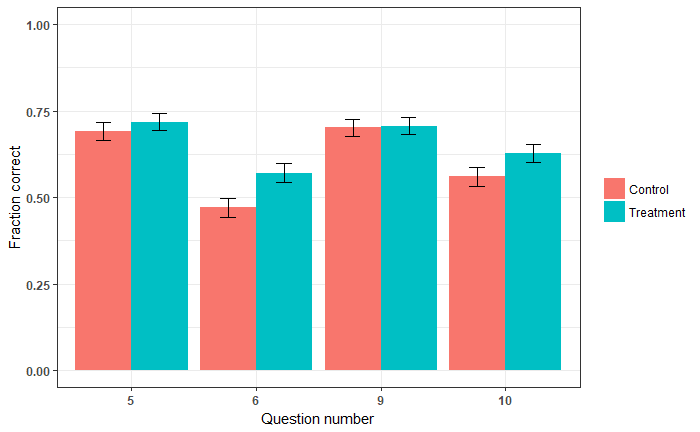

```r
dodge=position_dodge(width=0.9)
corr.by.question <- summarySE(
  dat.trt, measurevar="QCORRECT", groupvars=c("TREATMENT","QNUM")
  )
limits <- aes(ymax = QCORRECT + binomial.error, ymin = QCORRECT - binomial.error)
ggplot(corr.by.question, aes(x=QNUM, y=QCORRECT, fill=TREATMENT)) +
  geom_bar(stat="identity", position=dodge) +
  geom_errorbar(limits, position=dodge, width=0.25) +
  labs(x = "Question number", y = "Fraction correct") +
  scale_fill_discrete(labels=c("Control","Treatment")) +
  theme_bw() +
  theme(axis.text = element_text(face = "bold")) +
  #theme(legend.position="none")
  scale_y_continuous(limits = c(0,1)) +
  guides(fill=guide_legend(title=NULL))
```

```r
  #ggtitle("All")
```

### Fisher’s Exact for overall question set

```r
## fisher.2vector
# 2 vectors of 0s and 1s are passed
# * The first is control (top row)
# * The second is treatement (bottom row)
# Adding parenthesis around assigning a variable causes the output to be displayed
(result <- fisher.2vector(
  dat.trt$QCORRECT[dat.trt$TREATMENT==0],
  dat.trt$QCORRECT[dat.trt$TREATMENT==1]
))
```

```
    Fisher's Exact Test for Count Data

data:  ctable
p-value = 0.008497
alternative hypothesis: true odds ratio is not equal to 1
95 percent confidence interval:
 1.055850 1.460482
sample estimates:
odds ratio
  1.241638
```

```r
cat("Cohen's d\n ", cohens.d.from.odds.simple(result$estimate[[1]]),"\n")
```

```
Cohen's d
  0.1193251
```

### Simple logistic regression

```r
m <- glmer(QCORRECT ~ QNUM + TREATMENT + (1|ID),
                data = dat.trt,
                family = binomial, control=glmerControl(optimizer="bobyqa"))
print(summary(m))
```

```
Generalized linear mixed model fit by maximum likelihood (Laplace Approximation) ['glmerMod']
 Family: binomial  ( logit )
Formula: QCORRECT ~ QNUM + TREATMENT + (1 | ID)
   Data: dat.trt
Control: glmerControl(optimizer = "bobyqa")

     AIC      BIC   logLik deviance df.resid
  3339.2   3374.4  -1663.6   3327.2     2614

Scaled residuals:
    Min      1Q  Median      3Q     Max
-1.9040 -0.9880  0.5252  0.6962  1.3870

Random effects:
 Groups Name        Variance Std.Dev.
 ID     (Intercept) 0.6221   0.7887
Number of obs: 2620, groups:  ID, 658

Fixed effects:
            Estimate Std. Error z value Pr(>|z|)
(Intercept)  0.86542    0.10632   8.140 3.95e-16 ***
QNUM6       -0.89456    0.12503  -7.155 8.39e-13 ***
QNUM9        0.00195    0.12799   0.015  0.98784
QNUM10      -0.55054    0.12483  -4.410 1.03e-05 ***
TREATMENT1   0.24798    0.08771   2.827  0.00469 **
---
Signif. codes:  0 ‘***’ 0.001 ‘**’ 0.01 ‘*’ 0.05 ‘.’ 0.1 ‘ ’ 1

Correlation of Fixed Effects:
           (Intr) QNUM6  QNUM9  QNUM10
QNUM6      -0.641
QNUM9      -0.603  0.511
QNUM10     -0.632  0.539  0.513
TREATMENT1 -0.389 -0.017  0.002 -0.010
```

```r
#
se <- sqrt(diag(vcov(m)))
tab <- cbind(Est = fixef(m), LL = fixef(m) - 1.96 * se, UL = fixef(m) + 1.96 *se)
exp(tab)
```

```
                  Est        LL        UL
(Intercept) 2.3759910 1.9290626 2.9264644
QNUM6       0.4087861 0.3199384 0.5223071
QNUM9       1.0019522 0.7796460 1.2876461
QNUM10      0.5766358 0.4514868 0.7364754
TREATMENT1  1.2814361 1.0790391 1.5217969
```

### A quick summary of odds ratios so far

```r
odds.table <- matrix(c(result$estimate[[1]],exp(tab[[5]])),ncol=1,byrow=TRUE)
colnames(odds.table) <- c("Odds Ratio")
rownames(odds.table) <- c("Fisher's Exact Test","Logistic Regression")
as.table(odds.table)
```

```
                    Odds Ratio
Fisher's Exact Test   1.241638
Logistic Regression   1.281436
```

# Digging into the logistic regressions a bit more

### QNUM as a random effect

First, let’s look at making QNUM a random effect. Not sure if it is correct, but it makes no difference to the results and cleans up the reporting.

```r
m.2re <- glmer(QCORRECT ~ (1|QNUM) + TREATMENT + (1|ID),
                data = dat.trt,
                family = binomial, control=glmerControl(optimizer="bobyqa"))
summary(m.2re)$coefficients
```

```
             Estimate Std. Error  z value    Pr(>|z|)
(Intercept) 0.5001450 0.19507001 2.563926 0.010349569
TREATMENT1  0.2472692 0.08704356 2.840752 0.004500724
```

```r
summary(m.2re)
```

```
Generalized linear mixed model fit by maximum likelihood (Laplace Approximation) ['glmerMod']
 Family: binomial  ( logit )
Formula: QCORRECT ~ (1 | QNUM) + TREATMENT + (1 | ID)
   Data: dat.trt
Control: glmerControl(optimizer = "bobyqa")

     AIC      BIC   logLik deviance df.resid
  3352.2   3375.6  -1672.1   3344.2     2616

Scaled residuals:
    Min      1Q  Median      3Q     Max
-1.8220 -0.9899  0.5489  0.7015  1.3533

Random effects:
 Groups Name        Variance Std.Dev.
 ID     (Intercept) 0.6023   0.7761
 QNUM   (Intercept) 0.1333   0.3652
Number of obs: 2620, groups:  ID, 658; QNUM, 4

Fixed effects:
            Estimate Std. Error z value Pr(>|z|)
(Intercept)  0.50015    0.19507   2.564   0.0103 *
TREATMENT1   0.24727    0.08704   2.841   0.0045 **
---
Signif. codes:  0 ‘***’ 0.001 ‘**’ 0.01 ‘*’ 0.05 ‘.’ 0.1 ‘ ’ 1

Correlation of Fixed Effects:
           (Intr)
TREATMENT1 -0.215
```

### Fitting using all the questions

```r
#m.allQs <- glmer(QCORRECT ~ QNUM + TREATMENT + (1|ID),
#                data = dat.all,
#                family = binomial, control=glmerControl(optimizer="bobyqa"))
#summary(m.allQs)
```

```r
#m.allQs.2re <- glmer(QCORRECT ~ (1|QNUM) + TREATMENT + (1|ID),
#                data = dat.all,
#                family = binomial, control=glmerControl(optimizer="bobyqa"))
#summary(m.allQs.2re)
```

# Looking at other variables with only the treatment questions

## Course grade

```r
m.grade <- glmer(QCORRECT ~ QNUM + TREATMENT + course.grade.frac + NCRT + (1|ID),
                data = dat.trt,
                family = binomial, control=glmerControl(optimizer="bobyqa"))
summary(m.grade)
```

```
Generalized linear mixed model fit by maximum likelihood (Laplace Approximation) ['glmerMod']
 Family: binomial  ( logit )
Formula: QCORRECT ~ QNUM + TREATMENT + course.grade.frac + NCRT + (1 |      ID)
   Data: dat.trt
Control: glmerControl(optimizer = "bobyqa")

     AIC      BIC   logLik deviance df.resid
  3041.2   3088.1  -1512.6   3025.2     2612

Scaled residuals:
    Min      1Q  Median      3Q     Max
-2.9016 -0.8851  0.4482  0.6771  2.7981

Random effects:
 Groups Name        Variance Std.Dev.
 ID     (Intercept) 0.0198   0.1407
Number of obs: 2620, groups:  ID, 658

Fixed effects:
                   Estimate Std. Error z value Pr(>|z|)
(Intercept)       -3.422773   0.284928 -12.013  < 2e-16 ***
QNUM6             -0.904943   0.126218  -7.170 7.52e-13 ***
QNUM9              0.003465   0.130115   0.027  0.97875
QNUM10            -0.557258   0.126332  -4.411 1.03e-05 ***
TREATMENT1         0.244800   0.088502   2.766  0.00567 **
course.grade.frac  4.993186   0.383692  13.014  < 2e-16 ***
NCRT               0.305673   0.042914   7.123 1.06e-12 ***
---
Signif. codes:  0 ‘***’ 0.001 ‘**’ 0.01 ‘*’ 0.05 ‘.’ 0.1 ‘ ’ 1

Correlation of Fixed Effects:
            (Intr) QNUM6  QNUM9  QNUM10 TREATM crs.g.
QNUM6       -0.129
QNUM9       -0.231  0.515
QNUM10      -0.173  0.544  0.515
TREATMENT1  -0.183 -0.007  0.003  0.000
crs.grd.frc -0.900 -0.100  0.003 -0.059  0.029
NCRT        -0.044 -0.054 -0.002 -0.034  0.020 -0.218
```

# Time to dig into NCRT

## Graphs

### EYA performance vs NCRT and median split

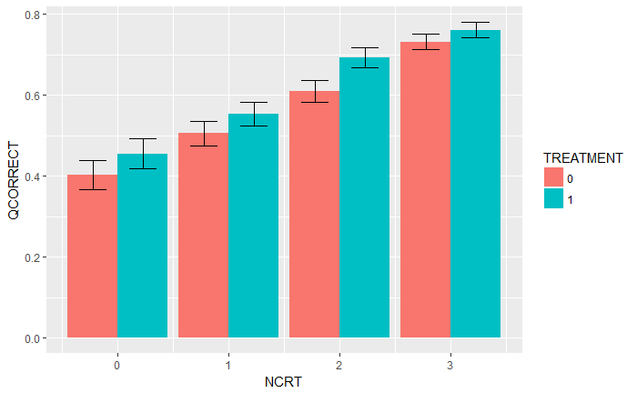

```r
s.ncrt <- summarySE(dat.trt, measurevar="QCORRECT",
                              groupvars=c("NCRT","TREATMENT"), .drop=FALSE)
limits <- aes(ymax = QCORRECT + binomial.error, ymin = QCORRECT - binomial.error)
#options(repr.plot.width=5, repr.plot.height=3)
ggplot(s.ncrt, aes(x=NCRT, y=QCORRECT, fill=TREATMENT)) +
    geom_bar(stat="identity", position=dodge) +
    geom_errorbar(limits, position=dodge, width=0.5)
```

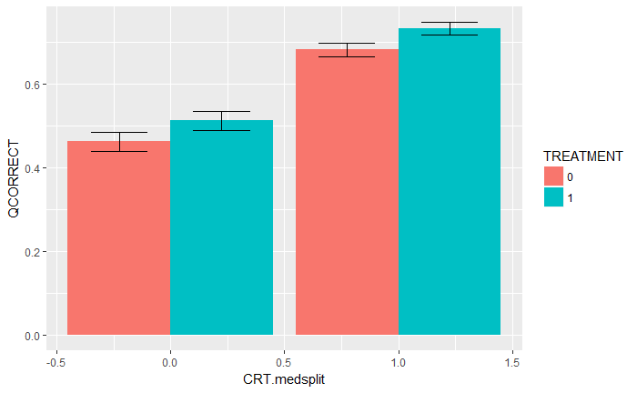

```r
s.crtsplit <- summarySE(dat.trt, measurevar="QCORRECT",
                              groupvars=c("CRT.medsplit","TREATMENT"), .drop=FALSE)
limits <- aes(ymax = QCORRECT + binomial.error, ymin = QCORRECT - binomial.error)
#options(repr.plot.width=5, repr.plot.height=3)
ggplot(s.crtsplit, aes(x=CRT.medsplit, y=QCORRECT, fill=TREATMENT)) +
    geom_bar(stat="identity", position=dodge) +
    geom_errorbar(limits, position=dodge, width=0.5)
```

# And looking at correlations with final exam grades

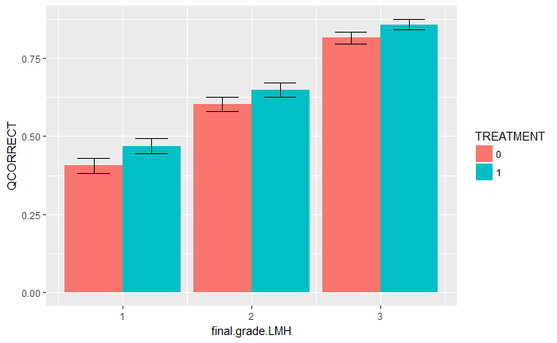

```r
s.fLMH <- summarySE(dat.trt, measurevar="QCORRECT",
                              groupvars=c("final.grade.LMH","TREATMENT"), .drop=FALSE)
limits <- aes(ymax = QCORRECT + binomial.error, ymin = QCORRECT - binomial.error)
#options(repr.plot.width=5, repr.plot.height=3)
ggplot(s.fLMH, aes(x=final.grade.LMH, y=QCORRECT, fill=TREATMENT)) +
    geom_bar(stat="identity", position=dodge) +
    geom_errorbar(limits, position=dodge, width=0.5)
```

# Finally, let’s look at gender

### Bar graph splitting on gender and looking at the effect of treatment

Splitting on gender shows that there may be a significant difference in who the intervention helps

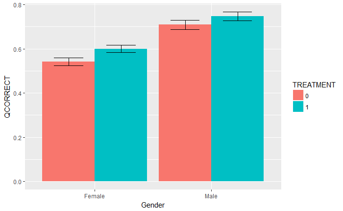

```r
sum.gender <- summarySE(dat.trt, measurevar="QCORRECT",
                              groupvars=c("Gender","TREATMENT"), .drop=FALSE)
limits <- aes(ymax = QCORRECT + binomial.error, ymin = QCORRECT - binomial.error)
ggplot(sum.gender, aes(x=Gender, y=QCORRECT, fill=TREATMENT)) +
    geom_bar(stat="identity", position=dodge) +
    geom_errorbar(limits, position=dodge, width=0.5)
```

### Logistic regression with gender added

Gender is significant.

```r
m.gender0 <- glmer(QCORRECT ~ QNUM + TREATMENT + Gender + (1|ID),
                data = dat.trt,
                family = binomial, control=glmerControl(optimizer="bobyqa"))
summary(m.gender0)
```

```
Generalized linear mixed model fit by maximum likelihood (Laplace Approximation) ['glmerMod']
 Family: binomial  ( logit )
Formula: QCORRECT ~ QNUM + TREATMENT + Gender + (1 | ID)
   Data: dat.trt
Control: glmerControl(optimizer = "bobyqa")

     AIC      BIC   logLik deviance df.resid
  3288.5   3329.5  -1637.2   3274.5     2613

Scaled residuals:
    Min      1Q  Median      3Q     Max
-2.2496 -0.9548  0.5067  0.6997  1.4685

Random effects:
 Groups Name        Variance Std.Dev.
 ID     (Intercept) 0.4913   0.7009
Number of obs: 2620, groups:  ID, 658

Fixed effects:
             Estimate Std. Error z value Pr(>|z|)
(Intercept)  0.567639   0.110691   5.128 2.93e-07 ***
QNUM6       -0.894988   0.125099  -7.154 8.41e-13 ***
QNUM9        0.000603   0.128207   0.005  0.99625
QNUM10      -0.552625   0.124938  -4.423 9.72e-06 ***
TREATMENT1   0.250017   0.087757   2.849  0.00439 **
GenderMale   0.793746   0.109970   7.218 5.28e-13 ***
---
Signif. codes:  0 ‘***’ 0.001 ‘**’ 0.01 ‘*’ 0.05 ‘.’ 0.1 ‘ ’ 1

Correlation of Fixed Effects:
           (Intr) QNUM6  QNUM9  QNUM10 TREATM
QNUM6      -0.596
QNUM9      -0.579  0.512
QNUM10     -0.595  0.540  0.513
TREATMENT1 -0.381 -0.018  0.002 -0.012
GenderMale -0.310 -0.055 -0.001 -0.034  0.024
```

### Run logistic regressions on the two gender populations seperately

First without course grades included. Treatment is only significant for females, not males.

```r
m.female <- glmer(QCORRECT ~ QNUM + TREATMENT + (1|ID),
                data = subset(dat.trt, Gender=="Female"),
                family = binomial, control=glmerControl(optimizer="bobyqa"))
summary(m.female)
```

```
Generalized linear mixed model fit by maximum likelihood (Laplace Approximation) ['glmerMod']
 Family: binomial  ( logit )
Formula: QCORRECT ~ QNUM + TREATMENT + (1 | ID)
   Data: subset(dat.trt, Gender == "Female")
Control: glmerControl(optimizer = "bobyqa")

     AIC      BIC   logLik deviance df.resid
  2161.7   2194.1  -1074.9   2149.7     1624

Scaled residuals:
    Min      1Q  Median      3Q     Max
-1.6950 -0.9826  0.5855  0.7996  1.5265

Random effects:
 Groups Name        Variance Std.Dev.
 ID     (Intercept) 0.4497   0.6706
Number of obs: 1630, groups:  ID, 409

Fixed effects:
            Estimate Std. Error z value Pr(>|z|)
(Intercept)  0.54798    0.12555   4.365 1.27e-05 ***
QNUM6       -0.97894    0.15394  -6.359 2.03e-10 ***
QNUM9       -0.01544    0.15396  -0.100  0.92011
QNUM10      -0.45561    0.15200  -2.997  0.00272 **
TREATMENT1   0.28553    0.10750   2.656  0.00791 **
---
Signif. codes:  0 ‘***’ 0.001 ‘**’ 0.01 ‘*’ 0.05 ‘.’ 0.1 ‘ ’ 1

Correlation of Fixed Effects:
           (Intr) QNUM6  QNUM9  QNUM10
QNUM6      -0.620
QNUM9      -0.614  0.500
QNUM10     -0.621  0.521  0.507
TREATMENT1 -0.395 -0.045  0.001 -0.029
```

```r
m<-m.female
se <- sqrt(diag(vcov(m)))
tab <- cbind(Est = fixef(m), LL = fixef(m) - 1.96 * se, UL = fixef(m) + 1.96 *se)
exp(tab)
```

```
                  Est        LL        UL
(Intercept) 1.7297536 1.3524364 2.2123388
QNUM6       0.3757092 0.2778549 0.5080255
QNUM9       0.9846771 0.7281771 1.3315293
QNUM10      0.6340631 0.4707062 0.8541124
TREATMENT1  1.3304630 1.0776980 1.6425120
```

```r
m.male <- glmer(QCORRECT ~ QNUM + TREATMENT + (1|ID),
                data = subset(dat.trt, Gender=="Male"),
                family = binomial, control=glmerControl(optimizer="bobyqa"))
summary(m.male)
```

```
Generalized linear mixed model fit by maximum likelihood (Laplace Approximation) ['glmerMod']
 Family: binomial  ( logit )
Formula: QCORRECT ~ QNUM + TREATMENT + (1 | ID)
   Data: subset(dat.trt, Gender == "Male")
Control: glmerControl(optimizer = "bobyqa")

     AIC      BIC   logLik deviance df.resid
  1131.6   1161.0   -559.8   1119.6      984

Scaled residuals:
    Min      1Q  Median      3Q     Max
-2.2693 -0.9380  0.4490  0.5734  1.0613

Random effects:
 Groups Name        Variance Std.Dev.
 ID     (Intercept) 0.6002   0.7747
Number of obs: 990, groups:  ID, 249

Fixed effects:
            Estimate Std. Error z value Pr(>|z|)
(Intercept)  1.42031    0.19600   7.246 4.28e-13 ***
QNUM6       -0.75169    0.21979  -3.420 0.000626 ***
QNUM9        0.03745    0.23347   0.160 0.872557
QNUM10      -0.74281    0.21958  -3.383 0.000717 ***
TREATMENT1   0.17833    0.15375   1.160 0.246091
---
Signif. codes:  0 ‘***’ 0.001 ‘**’ 0.01 ‘*’ 0.05 ‘.’ 0.1 ‘ ’ 1

Correlation of Fixed Effects:
           (Intr) QNUM6  QNUM9  QNUM10
QNUM6      -0.674
QNUM9      -0.591  0.527
QNUM10     -0.672  0.575  0.528
TREATMENT1 -0.392  0.032  0.005  0.028
```

```r
m<-m.male
se <- sqrt(diag(vcov(m)))
tab <- cbind(Est = fixef(m), LL = fixef(m) - 1.96 * se, UL = fixef(m) + 1.96 *se)
exp(tab)
```

```
                  Est        LL        UL
(Intercept) 4.1384133 2.8183316 6.0768095
QNUM6       0.4715667 0.3065180 0.7254882
QNUM9       1.0381613 0.6569490 1.6405823
QNUM10      0.4757749 0.3093769 0.7316696
TREATMENT1  1.1952190 0.8842524 1.6155439
```

When controlling for course grade, nothing changes

```r
m.female.grade <- glmer(QCORRECT ~ QNUM + TREATMENT + course.grade.frac + (1|ID),
                data = subset(dat.trt,Gender=="Female"),
                family = binomial, control=glmerControl(optimizer="bobyqa"))
summary(m.female.grade)
```

```
Generalized linear mixed model fit by maximum likelihood (Laplace Approximation) ['glmerMod']
 Family: binomial  ( logit )
Formula: QCORRECT ~ QNUM + TREATMENT + course.grade.frac + (1 | ID)
   Data: subset(dat.trt, Gender == "Female")
Control: glmerControl(optimizer = "bobyqa")

     AIC      BIC   logLik deviance df.resid
  2030.9   2068.7  -1008.5   2016.9     1623

Scaled residuals:
    Min      1Q  Median      3Q     Max
-2.1171 -0.9385  0.4891  0.7533  2.4850

Random effects:
 Groups Name        Variance Std.Dev.
 ID     (Intercept) 0.06234  0.2497
Number of obs: 1630, groups:  ID, 409

Fixed effects:
                  Estimate Std. Error z value Pr(>|z|)
(Intercept)        -3.2475     0.3539  -9.177  < 2e-16 ***
QNUM6              -0.9817     0.1543  -6.363 1.98e-10 ***
QNUM9              -0.0142     0.1553  -0.091  0.92714
QNUM10             -0.4558     0.1528  -2.983  0.00285 **
TREATMENT1          0.2801     0.1079   2.596  0.00944 **
course.grade.frac   5.2249     0.4699  11.119  < 2e-16 ***
---
Signif. codes:  0 ‘***’ 0.001 ‘**’ 0.01 ‘*’ 0.05 ‘.’ 0.1 ‘ ’ 1

Correlation of Fixed Effects:
            (Intr) QNUM6  QNUM9  QNUM10 TREATM
QNUM6       -0.114
QNUM9       -0.219  0.503
QNUM10      -0.174  0.523  0.508
TREATMENT1  -0.176 -0.035  0.001 -0.020
crs.grd.frc -0.938 -0.114 -0.001 -0.051  0.035
```

```r
m.male.grade <- glmer(QCORRECT ~ QNUM + TREATMENT + course.grade.frac + (1|ID),
                data = subset(dat.trt,Gender=="Male"),
                family = binomial, control=glmerControl(optimizer="bobyqa"))
summary(m.male.grade)
```

```
Generalized linear mixed model fit by maximum likelihood (Laplace Approximation) ['glmerMod']
 Family: binomial  ( logit )
Formula: QCORRECT ~ QNUM + TREATMENT + course.grade.frac + (1 | ID)
   Data: subset(dat.trt, Gender == "Male")
Control: glmerControl(optimizer = "bobyqa")

     AIC      BIC   logLik deviance df.resid
  1032.8   1067.1   -509.4   1018.8      983

Scaled residuals:
    Min      1Q  Median      3Q     Max
-3.5741 -0.5821  0.4021  0.5685  1.9337

Random effects:
 Groups Name        Variance Std.Dev.
 ID     (Intercept) 0.03624  0.1904
Number of obs: 990, groups:  ID, 249

Fixed effects:
                  Estimate Std. Error z value Pr(>|z|)
(Intercept)        -3.3260     0.5009  -6.640 3.13e-11 ***
QNUM6              -0.7723     0.2232  -3.461 0.000539 ***
QNUM9               0.0467     0.2383   0.196 0.844641
QNUM10             -0.7580     0.2230  -3.399 0.000676 ***
TREATMENT1          0.1741     0.1555   1.119 0.263030
course.grade.frac   6.1641     0.6521   9.453  < 2e-16 ***
---
Signif. codes:  0 ‘***’ 0.001 ‘**’ 0.01 ‘*’ 0.05 ‘.’ 0.1 ‘ ’ 1

Correlation of Fixed Effects:
            (Intr) QNUM6  QNUM9  QNUM10 TREATM
QNUM6       -0.166
QNUM9       -0.247  0.528
QNUM10      -0.170  0.581  0.529
TREATMENT1  -0.180  0.044  0.006  0.040
crs.grd.frc -0.926 -0.104  0.011 -0.099  0.020
```

### Looking at interaction term

```r
m.gender <- glmer(QCORRECT ~ QNUM + TREATMENT*Gender + (1|ID),
                data = dat.trt,
                family = binomial, control=glmerControl(optimizer="bobyqa"))
summary(m.gender)
```

```
Generalized linear mixed model fit by maximum likelihood (Laplace Approximation) ['glmerMod']
 Family: binomial  ( logit )
Formula: QCORRECT ~ QNUM + TREATMENT * Gender + (1 | ID)
   Data: dat.trt
Control: glmerControl(optimizer = "bobyqa")

     AIC      BIC   logLik deviance df.resid
  3290.1   3337.1  -1637.0   3274.1     2612

Scaled residuals:
    Min      1Q  Median      3Q     Max
-2.2060 -0.9461  0.4972  0.6930  1.4834

Random effects:
 Groups Name        Variance Std.Dev.
 ID     (Intercept) 0.492    0.7014
Number of obs: 2620, groups:  ID, 658

Fixed effects:
                        Estimate Std. Error z value Pr(>|z|)
(Intercept)            0.5505355  0.1143230   4.816 1.47e-06 ***
QNUM6                 -0.8972681  0.1251816  -7.168 7.62e-13 ***
QNUM9                  0.0004719  0.1282263   0.004  0.99706
QNUM10                -0.5546810  0.1250070  -4.437 9.11e-06 ***
TREATMENT1             0.2870489  0.1076585   2.666  0.00767 **
GenderMale             0.8476396  0.1425759   5.945 2.76e-09 ***
TREATMENT1:GenderMale -0.1110428  0.1858459  -0.597  0.55017
---
Signif. codes:  0 ‘***’ 0.001 ‘**’ 0.01 ‘*’ 0.05 ‘.’ 0.1 ‘ ’ 1

Correlation of Fixed Effects:
            (Intr) QNUM6  QNUM9  QNUM10 TREATMENT1 GndrMl
QNUM6       -0.568
QNUM9       -0.561  0.512
QNUM10      -0.568  0.540  0.513
TREATMENT1  -0.445 -0.034  0.001 -0.026
GenderMale  -0.389 -0.064 -0.002 -0.045  0.380
TREATMENT1:  0.250  0.033  0.002  0.029 -0.579     -0.636
```

```r
m<-m.gender
se <- sqrt(diag(vcov(m)))
tab <- cbind(Est = fixef(m), LL = fixef(m) - 1.96 * se, UL = fixef(m) + 1.96 *se)
exp(tab)
```

```
                            Est        LL        UL
(Intercept)           1.7341814 1.3860560 2.1697428
QNUM6                 0.4076819 0.3189809 0.5210485
QNUM9                 1.0004720 0.7781378 1.2863328
QNUM10                0.5742554 0.4494662 0.7336911
TREATMENT1            1.3324893 1.0790039 1.6455250
GenderMale            2.3341308 1.7650709 3.0866560
TREATMENT1:GenderMale 0.8949005 0.6216980 1.2881605
```

### Control for overall exam score (yes, re-calcuated for each question to not include the specific question in the score)

Treatment does not change significantly, but when controlling for final exam score the gender effect goes down significantly

```r
m.fgradeA <- glmer(QCORRECT ~ QNUM + TREATMENT + final.gradeA.fix + Gender + (1|ID),
                data = dat.trt,
                family = binomial, control=glmerControl(optimizer="bobyqa"))
summary(m.fgradeA)
```

```
Generalized linear mixed model fit by maximum likelihood (Laplace Approximation) ['glmerMod']
 Family: binomial  ( logit )
Formula: QCORRECT ~ QNUM + TREATMENT + final.gradeA.fix + Gender + (1 |      ID)
   Data: dat.trt
Control: glmerControl(optimizer = "bobyqa")

     AIC      BIC   logLik deviance df.resid
  3143.2   3190.1  -1563.6   3127.2     2612

Scaled residuals:
    Min      1Q  Median      3Q     Max
-3.3088 -0.9548  0.4817  0.7213  2.3850

Random effects:
 Groups Name        Variance Std.Dev.
 ID     (Intercept) 0        0
Number of obs: 2620, groups:  ID, 658

Fixed effects:
                 Estimate Std. Error z value Pr(>|z|)
(Intercept)      -1.42511    0.17934  -7.947 1.92e-15 ***
QNUM6            -0.89729    0.12255  -7.322 2.45e-13 ***
QNUM9             0.00104    0.12683   0.008  0.99346
QNUM10           -0.55284    0.12312  -4.490 7.12e-06 ***
TREATMENT1        0.24743    0.08636   2.865  0.00417 **
final.gradeA.fix  3.19745    0.24744  12.922  < 2e-16 ***
GenderMale        0.49859    0.09281   5.372 7.79e-08 ***
---
Signif. codes:  0 ‘***’ 0.001 ‘**’ 0.01 ‘*’ 0.05 ‘.’ 0.1 ‘ ’ 1

Correlation of Fixed Effects:
            (Intr) QNUM6  QNUM9  QNUM10 TREATM fnl.A.
QNUM6       -0.281
QNUM9       -0.355  0.518
QNUM10      -0.315  0.540  0.515
TREATMENT1  -0.258 -0.008  0.003 -0.003
fnl.grdA.fx -0.818 -0.094  0.001 -0.054  0.026
GenderMale  -0.032 -0.030 -0.002 -0.019  0.015 -0.156
```

```r
m.fgrade <- glmer(QCORRECT ~ QNUM + TREATMENT + final.grade.fix + Gender + (1|ID),
                data = dat.trt,
                family = binomial, control=glmerControl(optimizer="bobyqa"))
summary(m.fgrade)
```

```
Generalized linear mixed model fit by maximum likelihood (Laplace Approximation) ['glmerMod']
 Family: binomial  ( logit )
Formula: QCORRECT ~ QNUM + TREATMENT + final.grade.fix + Gender + (1 |      ID)
   Data: dat.trt
Control: glmerControl(optimizer = "bobyqa")

     AIC      BIC   logLik deviance df.resid
  3104.2   3151.1  -1544.1   3088.2     2612

Scaled residuals:
    Min      1Q  Median      3Q     Max
-3.4428 -0.9306  0.4630  0.7092  2.5240

Random effects:
 Groups Name        Variance  Std.Dev.
 ID     (Intercept) 1.148e-14 1.072e-07
Number of obs: 2620, groups:  ID, 658

Fixed effects:
                 Estimate Std. Error z value Pr(>|z|)
(Intercept)     -1.812548   0.191717  -9.454  < 2e-16 ***
QNUM6           -0.896874   0.123500  -7.262 3.81e-13 ***
QNUM9            0.001575   0.127780   0.012    0.990
QNUM10          -0.552219   0.124039  -4.452 8.51e-06 ***
TREATMENT1       0.244337   0.087036   2.807    0.005 **
final.grade.fix  3.729663   0.263766  14.140  < 2e-16 ***
GenderMale       0.505817   0.093251   5.424 5.82e-08 ***
---
Signif. codes:  0 ‘***’ 0.001 ‘**’ 0.01 ‘*’ 0.05 ‘.’ 0.1 ‘ ’ 1

Correlation of Fixed Effects:
            (Intr) QNUM6  QNUM9  QNUM10 TREATM fnl.g.
QNUM6       -0.261
QNUM9       -0.335  0.517
QNUM10      -0.295  0.539  0.515
TREATMENT1  -0.245 -0.005  0.003  0.000
finl.grd.fx -0.840 -0.092  0.001 -0.053  0.024
GenderMale  -0.044 -0.031 -0.002 -0.020  0.015 -0.126
```

```r
m.fgrade.int <- glmer(QCORRECT ~ QNUM + TREATMENT*Gender + final.grade.fix + (1|ID),
                data = dat.trt,
                family = binomial, control=glmerControl(optimizer="bobyqa"))
summary(m.fgrade.int)
```

```
Generalized linear mixed model fit by maximum likelihood (Laplace Approximation) ['glmerMod']
 Family: binomial  ( logit )
Formula: QCORRECT ~ QNUM + TREATMENT * Gender + final.grade.fix + (1 |      ID)
   Data: dat.trt
Control: glmerControl(optimizer = "bobyqa")

     AIC      BIC   logLik deviance df.resid
  3105.9   3158.7  -1543.9   3087.9     2611

Scaled residuals:
    Min      1Q  Median      3Q     Max
-3.3826 -0.9246  0.4642  0.7075  2.5032

Random effects:
 Groups Name        Variance  Std.Dev.
 ID     (Intercept) 4.702e-14 2.169e-07
Number of obs: 2620, groups:  ID, 658

Fixed effects:
                      Estimate Std. Error z value Pr(>|z|)
(Intercept)           -1.82838    0.19383  -9.433  < 2e-16 ***
QNUM6                 -0.89881    0.12357  -7.274 3.49e-13 ***
QNUM9                  0.00138    0.12780   0.011  0.99138
QNUM10                -0.55398    0.12410  -4.464 8.04e-06 ***
TREATMENT1             0.27866    0.10650   2.617  0.00888 **
GenderMale             0.55597    0.12951   4.293 1.76e-05 ***
final.grade.fix        3.72950    0.26371  14.142  < 2e-16 ***
TREATMENT1:GenderMale -0.10353    0.18490  -0.560  0.57552
---
Signif. codes:  0 ‘***’ 0.001 ‘**’ 0.01 ‘*’ 0.05 ‘.’ 0.1 ‘ ’ 1

Correlation of Fixed Effects:
            (Intr) QNUM6  QNUM9  QNUM10 TREATMENT1 GndrMl fnl.g.
QNUM6       -0.254
QNUM9       -0.331  0.517
QNUM10      -0.288  0.539  0.515
TREATMENT1  -0.283 -0.021  0.001 -0.015
GenderMale  -0.133 -0.043 -0.003 -0.033  0.405
finl.grd.fx -0.831 -0.092  0.001 -0.053  0.021     -0.089
TREATMENT1:  0.148  0.030  0.003  0.026 -0.576     -0.694 -0.002
```

```r
m<-m.fgrade.int
se <- sqrt(diag(vcov(m)))
tab <- cbind(Est = fixef(m), LL = fixef(m) - 1.96 * se, UL = fixef(m) + 1.96 *se)
exp(tab)
```

```
                             Est         LL         UL
(Intercept)            0.1606736  0.1098881  0.2349299
QNUM6                  0.4070535  0.3194996  0.5186002
QNUM9                  1.0013810  0.7794947  1.2864283
QNUM10                 0.5746600  0.4505866  0.7328982
TREATMENT1             1.3213578  1.0724332  1.6280608
GenderMale             1.7436241  1.3527281  2.2474767
final.grade.fix       41.6582357 24.8442523 69.8515124
TREATMENT1:GenderMale  0.9016484  0.6275512  1.2954637
```